# Co váží „typický“ savec?

### 9.3 Kategoriální nominální proměnná

**Kategoriální nominální proměnná** (*nominal categorical variable*; *nominal data*) rozděluje pozorování do kategorií, které nemají přirozené pořadí.

Příklady:

- druh nebo taxonomický řád,
- typ potravy,
- barva květu,
- krevní skupina,
- studijní skupina.

Pro nominální proměnnou obvykle zjišťujeme **četnostiPočet výskytů určité hodnoty nebo kategorie v datové sadě; pro kategoriální proměnné je četnost základní deskriptivní statistikou.** (*counts/frequencies*) nebo podíly kategorií. Průměr kódů kategorií nedává biologický smysl.

**Jak ji uvidíme v R?**

```r
# Vybereme sloupec s typem potravy.
vec_typ_potravy <- ggplot2::msleep[["vore"]]

# Chybějící údaje označíme viditelnou kategorií.
vec_typ_potravy[is.na(vec_typ_potravy)] <- "neuvedeno"

# Řekneme R, že hodnoty představují kategorie.
vec_typ_potravy <- factor(vec_typ_potravy)

# Zjistíme třídu objektu, jak ji popisuje R.
class(vec_typ_potravy)
```

```
[1] "factor"
```

```r
# Zjistíme, jak jsou kategorie technicky uložené.
typeof(vec_typ_potravy)
```

```
[1] "integer"
```

```r
# Zobrazíme strukturu včetně názvů kategorií.
str(vec_typ_potravy)
```

```
 Factor w/ 5 levels "carni","herbi",..: 1 5 2 5 2 2 1 4 1 2 ...
```

```r
# Spočítáme zastoupení jednotlivých kategorií.
table(vec_typ_potravy)
```

```
vec_typ_potravy
    carni     herbi   insecti neuvedeno      omni
       19        32         5         7        20
```

R zobrazuje nominální kategorie jako `factor` s několika úrovněmi (*levels*). `typeof()` přesto vrátí `integer`, protože faktor používá celá čísla jen jako vnitřní kódy pro textové štítky. Tyto kódy nejsou měření a nemá smysl je průměrovat.

**Četnosti**

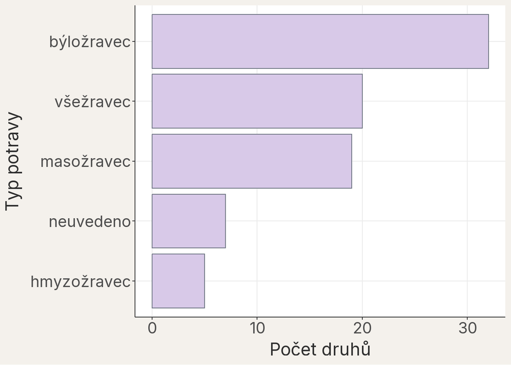

Počet druhů v jednotlivých kategoriích potravy.

**Podíly**

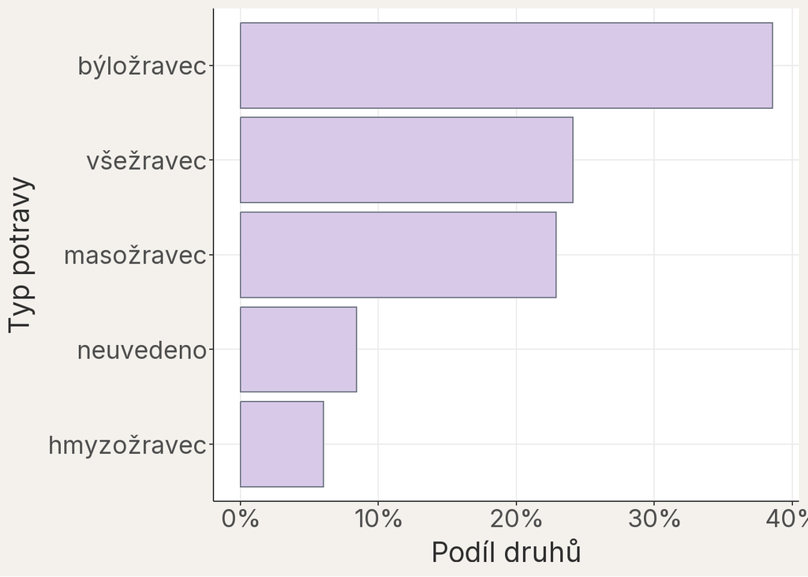

Podíl druhů v jednotlivých kategoriích potravy.

**UpozorněníČíselný kód není měření**

Když lokalitám přidělíme kódy 1, 2 a 3, nevznikne tím numerická proměnná. Výpočet průměru těchto kódů by závisel jen na našem libovolném číslování.

### 9.4 Kategoriální ordinální proměnná

**Kategoriální ordinální proměnná** (*ordinal categorical variable*; *ordinal data*) má kategorie s přirozeným pořadím, ale vzdálenosti mezi nimi nemusí být stejné.

Příklady:

- malý – střední – velký,
- mírný – střední – silný symptom,
- vývojové stadium,
- odpověď na škále „nesouhlasím“ až „souhlasím“,
- stupeň poškození listu.

V datasetu rozlišujeme tři seřazené velikostní kategorie: **lehký – střední – těžký**.

**Jak ji uvidíme v R?**

```r
# Vybereme sloupec s uspořádanou velikostní kategorií.
vec_velikost <- data_savci[["velikost"]]

# Pro tuto ukázku vynecháme řádky bez uvedené kategorie.
vec_velikost <- vec_velikost[!is.na(vec_velikost)]

# Zjistíme třídu objektu, jak ji popisuje R.
class(vec_velikost)
```

```
[1] "ordered" "factor"
```

```r
# Zjistíme, jak jsou kategorie technicky uložené.
typeof(vec_velikost)
```

```
[1] "integer"
```

```r
# Zobrazíme strukturu včetně pořadí kategorií.
str(vec_velikost)
```

```
 Ord.factor w/ 3 levels "lehký"<"střední"<..: 3 2 2 1 3 2 3 1 3 3 ...
```

```r
# Spočítáme zastoupení jednotlivých kategorií.
table(vec_velikost)
```

```
vec_velikost
  lehký střední   těžký
     28      27      28
```

R tento objekt označí třídami `ordered` a `factor`. Vnitřní uložení je opět `integer`, ale pořadí úrovní „lehký“ < „střední“ < „těžký“ je součástí objektu. Právě tím se ordinální faktor liší od nominálního faktoru.

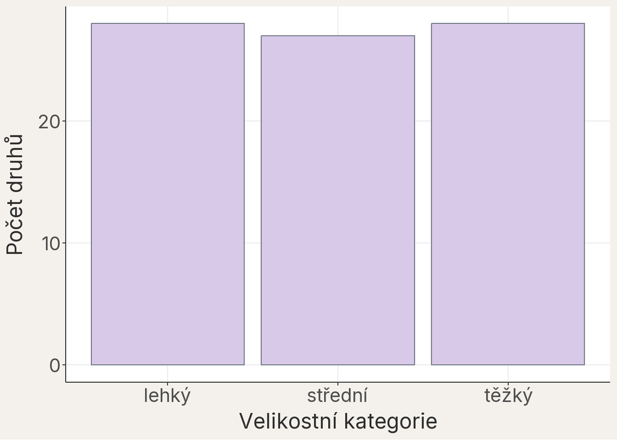

U ordinální proměnné zachováváme přirozené pořadí kategorií.

**PoznámkaU ordinální proměnné zachováváme pořadí**

Kategorie nejsou zaměnitelné: **lehký < střední < těžký**. Toto pořadí musí zůstat zachované v objektu v R, v tabulce i v grafu.

### 9.5 Procvičení: určete typ proměnné

Možnosti jsou:

- numerická spojitá;
- numerická diskrétní;
- kategoriální nominální;
- kategoriální ordinální.

Určete typ každé proměnné. Zatím nemusíte vybírat graf:

1. pH vody v rybníce,
2. počet žab odchycených za noc,
3. druh stanoviště,
4. stupeň napadení rostliny: žádný – mírný – silný,
5. identifikační číslo jedince.

**DůležitéŘešení: určete typ proměnné**

1. pH: numerická spojitá.
2. Počet žab: numerická diskrétní.
3. Druh stanoviště: kategoriální nominální.
4. Stupeň napadení: kategoriální ordinální.
5. Identifikační číslo: identifikátor, nikoli měřená numerická proměnná.

### 9.6 Přehled: od typu proměnné k vhodnému popisu

[output not shown]

**PoznámkaPořadí rozhodování**

1. Co představuje jeden řádek?
2. Co proměnná znamená a jak vznikla?
3. Jakého je typu?
4. Který graf ukáže jednotlivé hodnoty nebo rozdělení?
5. Který číselný souhrn odpovídá tvaru dat a biologické otázce?

## 10 Shrnutí

V této lekci jsme prošli celou cestu od měření k popisu dat:

1. jedno pozorováníJeden zaznamenaný případ v datech, který obsahuje hodnoty jedné nebo více proměnných. jsme zapsali do řádku tabulky;
2. jednu proměnnouVlastnost zaznamenaná u pozorování, která může mezi pozorováními nabývat různých hodnot, například druh, délka nebo počet. jsme vybrali jako vektor v R a zkontrolovali pomocí `length()` a `head()`;
3. před výpočtem statistik jsme se podívali na jednotlivé hodnoty a rozděleníPopis toho, jaké hodnoty proměnná nabývá a jak často se vyskytují; může jít o pozorované rozdělení dat nebo o teoretické pravděpodobnostní rozdělení.;
4. průměrSoučet hodnot vydělený jejich počtem; nejběžnější míra polohy (střední hodnoty)., mediánHodnota rozdělující seřazená data na dvě stejně početné poloviny; 50. percentil., kvartilyHodnota, pod níž leží určený podíl seřazených dat; medián je 50% kvantil., IQRRozdíl mezi 3. kvartilem (Q3) a 1. kvartilem (Q1); pokrývá prostředních 50 % dat a je robustní vůči odlehlým pozorováním., minimum, maximum a SDOdmocnina rozptylu; vyjadřuje průměrnou vzdálenost hodnot od průměru ve stejných jednotkách jako původní data. jsme propojili s grafem;
5. krok za krokem jsme z těchto myšlenek postavili krabicový grafGraf, jehož krabice sahá od Q1 do Q3 a obsahuje medián; vousy vymezují hodnoty podle zvoleného pravidla a body za nimi upozorňují na možná odlehlá pozorování.;
6. nakonec jsme rozlišili spojitéNumerická proměnná, která může v principu nabývat libovolné hodnoty v určitém intervalu, například délka, hmotnost nebo čas., diskrétníNumerická proměnná s oddělenými, spočetnými možnými hodnotami, například počet jedinců nebo počet událostí., nominálníKategoriální proměnná, jejíž kategorie nemají přirozené pořadí, například druh, ostrov nebo barva. a ordinálníKategoriální proměnná s přirozeně seřazenými kategoriemi, jejichž vzájemné vzdálenosti však nemusí být stejné nebo známé. proměnné.

Neexistuje jedno „nejlepší“ číslo ani jeden „nejlepší“ graf pro všechna data. Pro číselná data často používáme dvě užitečné dvojice: **průměr + SD** nebo **medián + IQR**. Volba závisí na typu proměnné, tvaru dat, pozorovací jednotceEntita nebo děj, o kterém jedno pozorování nese informace, například jedinec, plocha, vzorek vody nebo jedna erupce. a otázce, kterou chceme zodpovědět.

**Význam proměnné určuje její statistický typ.** Teprve podle něj vybíráme smysluplný graf a číselný souhrn. A stejně jako u titulku o „běžném“ savci platí: správný výpočet ještě nestačí — musíme vidět data a vědět, co představuje jeden řádek.

### 10.1 Závěrečná otázka

Představte si nový dataset o rostlinách. Každý řádek je jedna rostlina a sloupce obsahují druh, výšku, počet květů a stupeň poškození listů.

> Kterou proměnnou byste prozkoumali jako první, jakým grafem a jakou dvojicí statistik? Dokážete svou volbu zdůvodnit?

## 11 Most k další lekci

Zatím jsme zkoumali vždy jednu proměnnouVlastnost zaznamenaná u pozorování, která může mezi pozorováními nabývat různých hodnot, například druh, délka nebo počet.. V další lekci se zaměříme na otázku, jak data získat, načíst a uspořádat tak, aby byla připravena pro podobné grafy a výpočty. Později začneme porovnávat skupiny a hledat vztahy mezi proměnnými.

## 12 Slovníček

V HTML verzi se definice pojmů zobrazují také po najetí kurzorem na podtržený pojem.

| term | definition |
| --- | --- |
| boxplot | Graf, jehož krabice sahá od Q1 do Q3 a obsahuje medián; vousy vymezují hodnoty podle zvoleného pravidla a body za nimi upozorňují na možná odlehlá pozorování. |
| cetnost | Počet výskytů určité hodnoty nebo kategorie v datové sadě; pro kategoriální proměnné je četnost základní deskriptivní statistikou. |
| diskretni-promenna | Numerická proměnná s oddělenými, spočetnými možnými hodnotami, například počet jedinců nebo počet událostí. |
| histogram | Graf zobrazující rozdělení hodnot numerické proměnné: hodnoty jsou seřazeny do tříd, výška sloupce udává četnost v dané třídě. |
| iqr | Rozdíl mezi 3. kvartilem (Q3) a 1. kvartilem (Q1); pokrývá prostředních 50 % dat a je robustní vůči odlehlým pozorováním. |
| jednotka-pozorovani | Entita nebo děj, o kterém jedno pozorování nese informace, například jedinec, plocha, vzorek vody nebo jedna erupce. |
| kvantil | Hodnota, pod níž leží určený podíl seřazených dat; medián je 50% kvantil. |
| median | Hodnota rozdělující seřazená data na dvě stejně početné poloviny; 50. percentil. |
| nejistota | Rozsah, v němž nevíme přesnou hodnotu parametru kvůli omezenému a variabilnímu vzorku; kvantifikuje se pomocí intervalů spolehlivosti nebo směrodatných chyb. |
| nominalni-promenna | Kategoriální proměnná, jejíž kategorie nemají přirozené pořadí, například druh, ostrov nebo barva. |
| odhad | Číslo vypočtené z pozorovaných dat jako přiblížení neznámé vlastnosti nebo parametru; jiný srovnatelný výběr může dát jiný odhad. |
| odlehla-pozorovani | Hodnota, která se výrazně odlišuje od ostatních pozorování; může být způsobena chybou měření nebo jít o skutečně extrémní případ. |
| ordinalni-promenna | Kategoriální proměnná s přirozeně seřazenými kategoriemi, jejichž vzájemné vzdálenosti však nemusí být stejné nebo známé. |
| pozorovani | Jeden zaznamenaný případ v datech, který obsahuje hodnoty jedné nebo více proměnných. |
| promenna | Vlastnost zaznamenaná u pozorování, která může mezi pozorováními nabývat různých hodnot, například druh, délka nebo počet. |
| prumer | Součet hodnot vydělený jejich počtem; nejběžnější míra polohy (střední hodnoty). |
| rozdeleni | Popis toho, jaké hodnoty proměnná nabývá a jak často se vyskytují; může jít o pozorované rozdělení dat nebo o teoretické pravděpodobnostní rozdělení. |
| rozptyl | Průměr čtverců odchylek od průměru; míra variability dat. Odmocnina rozptylu je směrodatná odchylka. |
| sklon | Parametr lineárního modelu udávající, o kolik se změní odezva, pokud prediktor vzroste o jednu jednotku (při zachování ostatních prediktorů). |
| sloupcovy-graf | Graf kategoriální proměnné, v němž výška nebo délka oddělených sloupců představuje četnosti, podíly nebo jiný souhrn kategorií. |
| smerodatna-odchylka | Odmocnina rozptylu; vyjadřuje průměrnou vzdálenost hodnot od průměru ve stejných jednotkách jako původní data. |
| spojita-promenna | Numerická proměnná, která může v principu nabývat libovolné hodnoty v určitém intervalu, například délka, hmotnost nebo čas. |
| standardni-chyba | Míra přesnosti odhadu parametru (typicky průměru) z dat; udává, jak moc by se odhadnutý parametr lišil při opakovaném vzorkování ze stejné populace. |
| variabilita | Obecný termín pro rozsah, v němž se hodnoty proměnné liší od sebe navzájem; kvantifikuje se pomocí rozptylu, SD, IQR nebo rozsahu. |
| vyber | Soubor pozorování, z něhož počítáme statistiky a pomocí něhož se snažíme popsat širší populaci nebo proces. |